# HDAT9600 Final Team 2 Assignment

Please see course outline / ‘Announcements’ for submission deadline

Team 2: Annie, Jason, Yosuke, Tiffany

Aug 19, 2022

### Task 1

```r
# Subsetting the ICU dataset into variables of interest and removing rows where SOFA is negative
icu_sub <- icu_patients_df1 %>% dplyr::select(in_hospital_death, ICUType, Age, SOFA, FiO2_max, RespRate_min) %>% filter(SOFA != -1)

# Getting the summary statistics of the dataset
sumtable(icu_sub)
```

Summary Statistics

| Variable | N | Mean | Std. Dev. | Min | Pctl. 25 | Pctl. 75 | Max |
| --- | --- | --- | --- | --- | --- | --- | --- |
| in_hospital_death | 1996 | 0.147 | 0.354 | 0 | 0 | 0 | 1 |
| ICUType | 1996 |  |  |  |  |  |  |
| … Coronary Care Unit | 287 | 14.4% |  |  |  |  |  |
| … Cardiac Surgery Recovery Unit | 446 | 22.3% |  |  |  |  |  |
| … Medical ICU | 757 | 37.9% |  |  |  |  |  |
| … Surgical ICU | 506 | 25.4% |  |  |  |  |  |
| Age | 1996 | 64.52 | 17.397 | 16 | 53 | 78 | 90 |
| SOFA | 1996 | 6.683 | 4.042 | 0 | 3 | 9 | 22 |
| FiO2_max | 1996 | 0.789 | 0.248 | 0.28 | 0.5 | 1 | 1 |
| RespRate_min | 1996 | 14.251 | 3.792 | 4 | 12 | 17 | 24 |

*We had a look at all the variables in the dataset before making a selection of 6 variables which we will investigate.*

*We selected the predictor variables (age,ICU type, SOFA score, maximum fractional inspired oxygen (FiO2) and minimum respiration rate) to predict the risk of in-hospital death.*

**Background Research supporting the selection of predictor variables**

*Based on the article “Relationship between age and in-hospital mortality during 15,345,025 non-surgical hospitalizations” from the Archives of Medical Science, the findings support in hospital death to be associated with the age of the patients. In this study, older patients have a greater odds of dying in hospital than younger patients.*  
*In this article, “Infection as an independent risk factor for mortality in the surgical intensive care unit” from National Library of Medicine which evaluated mortality in hospital from surgical and medical ICU, points out that certain types of ICU are associated with high in hospital mortality.*  
*Additionally, “Prognostic Accuracy of the SOFA Score, SIRS Criteria, and SOFA Score for In-Hospital Mortality Among Adults With Suspected Infection Admitted to the Intensive Care Unit” from PubMed propose that high SOFA scores are associated with higher in hospital mortality.*  
*According to “Severity of respiratory failure at admission and in-hospital mortality in patients with COVID-19: a prospective observational multicentre study” from BMJ reports high FiO2 is independently associated with in-hospital mortality.*  
*Lastly, “Mean nocturnal respiratory rate predicts cardiovascular and all-cause mortality in community-dwelling older men and women” from ERS reports that the association between low respiratory rate and in hospital and short term mortality.*

```r
# Turn in_hospital_death variable to factor variables
icu_sub$in_hospital_death <- as.integer(as.factor(icu_sub$in_hospital_death)) - 1
```

*The subset of ICU dataset has no missing data.*

[figure not shown]

```r
# for loop to produce all the plots to compare the distribution
 names <- colnames(icu_sub[-c(1:2)])
plots <- list()
  for (column in names) {
 plots[[column]] <- ggplot(data = icu_sub, aes(x = icu_sub[,column], fill = factor(in_hospital_death)))+ geom_histogram(bins = 30) + theme_minimal() + scale_x_continuous(expand = c(0,0)) + scale_y_continuous(expand = c(0,0)) + ggtitle(paste("Histogram of", column)) + labs(x = column, fill = "Deaths in Hospital") + facet_grid(in_hospital_death~., scales = "fixed")+ scale_fill_discrete(name = "Deaths in Hospital", labels = c("Survivor", "Died in Hospital"))
}
do.call(grid.arrange, plots)
```

```r
# Fitting univariate logistic regression models
age_glm <- glm(in_hospital_death ~ Age, family = binomial, data = icu_sub)
Icu_type_glm <- glm(in_hospital_death ~ ICUType, family = binomial, data = icu_sub)
SOFA_glm <- glm(in_hospital_death ~ SOFA, family = binomial, data = icu_sub)
FiO2_glm <- glm(in_hospital_death ~ FiO2_max, family = binomial, data = icu_sub)
RespRate_glm <- glm(in_hospital_death ~ RespRate_min, family = binomial, data = icu_sub)
AIC(age_glm, Icu_type_glm, SOFA_glm, FiO2_glm, RespRate_glm)
```

|  | df | AIC |
| --- | --- | --- |
| age_glm | 2 | 1612.995 |
| Icu_type_glm | 4 | 1626.341 |
| SOFA_glm | 2 | 1581.240 |
| FiO2_glm | 2 | 1668.890 |
| RespRate_glm | 2 | 1643.241 |

```r
# Using AIC for model selection
full_mod <- glm(in_hospital_death~., family = binomial, data = icu_sub)
aic_suggest_mod <- stepAIC(full_mod, direction="both", scope=list(lower=~1, upper=~.^2), trace=F, data=icu_sub)
tab_model(aic_suggest_mod, show.intercept = TRUE, show.est = TRUE, show.ci = FALSE, show.se = TRUE, show.p = TRUE, show.stat = TRUE, show.aic = TRUE, show.dev = TRUE, show.r2 = FALSE, show.fstat = TRUE, show.obs = FALSE)
```

|  | in hospital death |  |  |  |
| --- | --- | --- | --- | --- |
| Predictors | Odds Ratios | std. Error | Statistic | p |
| (Intercept) | 0.00 | 0.00 | -5.01 | **<0.001** |
| ICUType [Cardiac Surgery Recovery Unit] | 1.66 | 2.92 | 0.29 | 0.774 |
| ICUType [Medical ICU] | 1.20 | 1.52 | 0.15 | 0.884 |
| ICUType [Surgical ICU] | 0.13 | 0.18 | -1.45 | 0.147 |
| Age | 1.04 | 0.02 | 2.45 | **0.014** |
| SOFA | 1.56 | 0.15 | 4.73 | **<0.001** |
| RespRate min | 1.03 | 0.02 | 1.72 | 0.085 |
| ICUType [Cardiac Surgery Recovery Unit] * SOFA | 0.78 | 0.06 | -3.22 | **0.001** |
| ICUType [Medical ICU] * SOFA | 0.91 | 0.05 | -1.82 | 0.068 |
| ICUType [Surgical ICU] * SOFA | 0.92 | 0.05 | -1.55 | 0.122 |
| Age * SOFA | 1.00 | 0.00 | -2.46 | **0.014** |
| ICUType [Cardiac Surgery Recovery Unit] * Age | 1.00 | 0.02 | 0.07 | 0.946 |
| ICUType [Medical ICU] * Age | 1.01 | 0.02 | 0.58 | 0.559 |
| ICUType [Surgical ICU] * Age | 1.04 | 0.02 | 2.12 | **0.034** |
| Deviance | 1409.259 |  |  |  |
| AIC | 1437.259 |  |  |  |

*The AIC suggested models only contain four predictor variables which are type of ICU, age, SOFA score and minimum respiration rate with 3 interactions which are ICUTypeCardiac Surgery Recovery Unit:SOFA, Age:SOFA and ICUTypeSurgical ICU:Age.*

```r
# Model suggested by AIC
reduced_interactions1 <- glm(in_hospital_death ~ ICUType + Age + SOFA + RespRate_min +
    ICUType:SOFA + Age:SOFA + ICUType:Age, family = binomial, data = icu_sub)

# Tried to see if it dropping the minimum respiration rate would make any difference as the p-value is above 0.05
reduced_interactions2 <- glm(in_hospital_death ~ ICUType + Age + SOFA +
    ICUType:SOFA + Age:SOFA + ICUType:Age, family = binomial, data = icu_sub)

# display the results of both models
tab_model(reduced_interactions1, reduced_interactions2, show.intercept = TRUE, show.est = TRUE, show.ci = FALSE, show.se = TRUE, show.p = TRUE, show.stat = TRUE, show.aic = TRUE, show.dev = TRUE, show.r2 = FALSE, show.fstat = TRUE, show.obs = FALSE, dv.labels = c("reduced_interactions1", "reduced_interactions2"))
```

|  | reduced_interactions1 |  |  |  | reduced_interactions2 |  |  |  |
| --- | --- | --- | --- | --- | --- | --- | --- | --- |
| Predictors | Odds Ratios | std. Error | Statistic | p | Odds Ratios | std. Error | Statistic | p |
| (Intercept) | 0.00 | 0.00 | -5.01 | **<0.001** | 0.00 | 0.00 | -4.76 | **<0.001** |
| ICUType [Cardiac Surgery Recovery Unit] | 1.66 | 2.92 | 0.29 | 0.774 | 1.38 | 2.44 | 0.18 | 0.854 |
| ICUType [Medical ICU] | 1.20 | 1.52 | 0.15 | 0.884 | 1.19 | 1.51 | 0.14 | 0.888 |
| ICUType [Surgical ICU] | 0.13 | 0.18 | -1.45 | 0.147 | 0.12 | 0.17 | -1.47 | 0.141 |
| Age | 1.04 | 0.02 | 2.45 | **0.014** | 1.04 | 0.02 | 2.42 | **0.016** |
| SOFA | 1.56 | 0.15 | 4.73 | **<0.001** | 1.58 | 0.15 | 4.87 | **<0.001** |
| RespRate min | 1.03 | 0.02 | 1.72 | 0.085 |  |  |  |  |
| ICUType [Cardiac Surgery Recovery Unit] * SOFA | 0.78 | 0.06 | -3.22 | **0.001** | 0.78 | 0.06 | -3.23 | **0.001** |
| ICUType [Medical ICU] * SOFA | 0.91 | 0.05 | -1.82 | 0.068 | 0.91 | 0.05 | -1.92 | 0.054 |
| ICUType [Surgical ICU] * SOFA | 0.92 | 0.05 | -1.55 | 0.122 | 0.91 | 0.05 | -1.66 | 0.098 |
| Age * SOFA | 1.00 | 0.00 | -2.46 | **0.014** | 1.00 | 0.00 | -2.49 | **0.013** |
| ICUType [Cardiac Surgery Recovery Unit] * Age | 1.00 | 0.02 | 0.07 | 0.946 | 1.00 | 0.02 | 0.15 | 0.877 |
| ICUType [Medical ICU] * Age | 1.01 | 0.02 | 0.58 | 0.559 | 1.01 | 0.02 | 0.62 | 0.535 |
| ICUType [Surgical ICU] * Age | 1.04 | 0.02 | 2.12 | **0.034** | 1.04 | 0.02 | 2.15 | **0.031** |
| Deviance | 1409.259 |  |  |  | 1412.223 |  |  |  |
| AIC | 1437.259 |  |  |  | 1438.223 |  |  |  |

```r
# Running an analysis of deviance
print(anova(reduced_interactions2, reduced_interactions1, test = "Chi"))
```

```
## Analysis of Deviance Table
##
## Model 1: in_hospital_death ~ ICUType + Age + SOFA + ICUType:SOFA + Age:SOFA +
##     ICUType:Age
## Model 2: in_hospital_death ~ ICUType + Age + SOFA + RespRate_min + ICUType:SOFA +
##     Age:SOFA + ICUType:Age
##   Resid. Df Resid. Dev Df Deviance Pr(>Chi)
## 1      1983     1412.2
## 2      1982     1409.3  1   2.9635  0.08516 .
## ---
## Signif. codes:  0 '***' 0.001 '**' 0.01 '*' 0.05 '.' 0.1 ' ' 1
```

*From the analysis of deviance, the p-value is above 0.05, showing that minimum respiration rate is not a significant predictor of in-hospital deaths. Even though the AIC for the second model is 1438.2 which is 0.9 higher then the model fitted by earlier, the simpler model is preferred based on the analysis of deviance.*

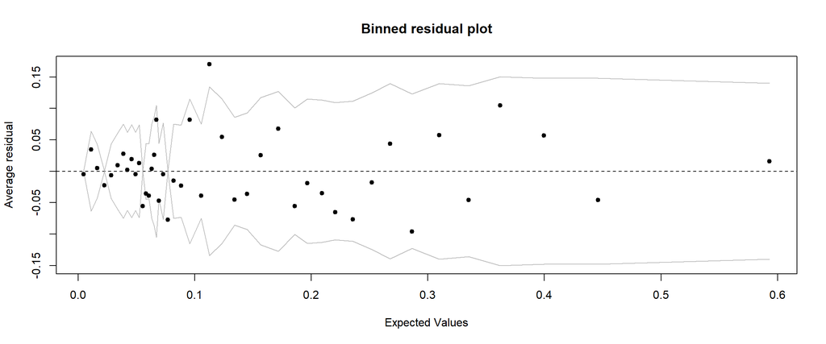

```r
# Checking the model fit using binned residual plot
binnedplot(predict(reduced_interactions2, type="response"), residuals(reduced_interactions2, type="response"))
```

*The variance of the residuals in the binned residual plot seems to be constant and evenly distributed.*

```r
# Checking the goodness of fit of reduced model using Brier Score test
pred_prob_reduced <- predict(reduced_interactions1, type = "response")
brier_score_reduced <- mean((pred_prob_reduced - icu_sub$in_hospital_death)^2)
brier_score_reduced
```

```
## [1] 0.1072906
```

```r
# Checking the goodness of fit of reduced model with interaction using Brier Score test
pred_prob_reduced_interactions2 <- predict(reduced_interactions2, type = "response")
brier_score_reduced <- mean((pred_prob_reduced_interactions2 - icu_sub$in_hospital_death)^2)
brier_score_reduced
```

```
## [1] 0.1074341
```

*The difference in Brier scores between the two is very small, therefore the second model without minimum respiration rate is preferred based on the analysis of deviance conducted earlier.*

Unsurprisingly, according to our model `reduced_interactions2`, an increase in `Age` and `SOFA` (Sequential Organ Failure Assessment) score increased mortality. For every year increase of `Age`, there is ~4% increase in mortality. For every `SOFA` point increase, there is a ~58% increase in mortality.

```r
unimputed <- glm(in_hospital_death ~ ICUType + Age + SOFA +
    ICUType:SOFA + Age:SOFA + ICUType:Age, family = binomial, data = icu_patients_df0)
tab_model(unimputed, show.intercept = TRUE, show.est = TRUE, show.ci = FALSE, show.se = TRUE, show.p = TRUE, show.stat = TRUE, show.aic = TRUE, show.dev = TRUE, show.r2 = FALSE, show.fstat = TRUE, show.obs = FALSE)
```

|  | in hospital death |  |  |  |
| --- | --- | --- | --- | --- |
| Predictors | Odds Ratios | std. Error | Statistic | p |
| (Intercept) | 0.00 | 0.00 | -4.52 | **<0.001** |
| ICUType [Cardiac Surgery Recovery Unit] | 1.19 | 2.04 | 0.10 | 0.921 |
| ICUType [Medical ICU] | 1.02 | 1.25 | 0.02 | 0.985 |
| ICUType [Surgical ICU] | 0.20 | 0.27 | -1.18 | 0.238 |
| Age | 1.03 | 0.02 | 2.12 | **0.034** |
| SOFA | 1.47 | 0.13 | 4.31 | **<0.001** |
| ICUType [Cardiac Surgery Recovery Unit] * SOFA | 0.79 | 0.06 | -3.06 | **0.002** |
| ICUType [Medical ICU] * SOFA | 0.93 | 0.05 | -1.55 | 0.120 |
| ICUType [Surgical ICU] * SOFA | 0.91 | 0.05 | -1.79 | 0.074 |
| Age * SOFA | 1.00 | 0.00 | -1.84 | 0.065 |
| ICUType [Cardiac Surgery Recovery Unit] * Age | 1.00 | 0.02 | 0.15 | 0.883 |
| ICUType [Medical ICU] * Age | 1.01 | 0.02 | 0.60 | 0.547 |
| ICUType [Surgical ICU] * Age | 1.03 | 0.02 | 1.85 | 0.064 |
| Deviance | 1450.893 |  |  |  |
| AIC | 1476.893 |  |  |  |

```r
# calculate p-value
(p_unimputed <- 1 - pchisq(unimputed$null.deviance - unimputed$deviance, unimputed$df.null - unimputed$df.residual))
```

```
## [1] 0
```

```r
(p_imputed <- 1 - pchisq(reduced_interactions2$null.deviance - reduced_interactions2$deviance, reduced_interactions2$df.null - reduced_interactions2$df.residual))
```

```
## [1] 0
```

```r
# null model
reduced_null <-glm(in_hospital_death ~ 1, family = binomial, data = icu_sub)

# calculate p-value
print(anova(reduced_null, reduced_interactions2, test = "Chi"))
```

```
## Analysis of Deviance Table
##
## Model 1: in_hospital_death ~ 1
## Model 2: in_hospital_death ~ ICUType + Age + SOFA + ICUType:SOFA + Age:SOFA +
##     ICUType:Age
##   Resid. Df Resid. Dev Df Deviance  Pr(>Chi)
## 1      1995     1665.1
## 2      1983     1412.2 12   252.87 < 2.2e-16 ***
## ---
## Signif. codes:  0 '***' 0.001 '**' 0.01 '*' 0.05 '.' 0.1 ' ' 1
```

*Looking through the summary statistics and p-values of the imputed and the unimputed datasets, the ICUTypeSurgical ICU:Age interaction and Age:SOFA interaction became insignificant and in the unimputed dataset. The AIC for the unimputed dataset is 1476.9 which is much higher than the AIC for the imputed dataset of 1438.2. This means that the model is a better fit for the imputed dataset.*

**Summary Findings**

=====

The explanatory variables I will use to predict survival will include:

I will create a subset of the `icu_patients_df1` with the above predictor variables, and the outcome variables `Days` (survival) and `Status` (censoring).

```r
icu_sub2 <- icu_patients_df1 %>% dplyr::select(Days, Status, Age, HR_max, RespRate_max, SaO2_max, NISysABP_max, Urine_min, Temp_max, GCS_max, Lactate_max, HCT_max, Creatinine_max, Na_max)
icu_sub2c <- na.omit(icu_sub2)
attach(icu_sub2)
```

A brief exploratory data analysis is performed on the variables of interest. We show a survival curve for the overall data and density maps for each variable stratified by status.

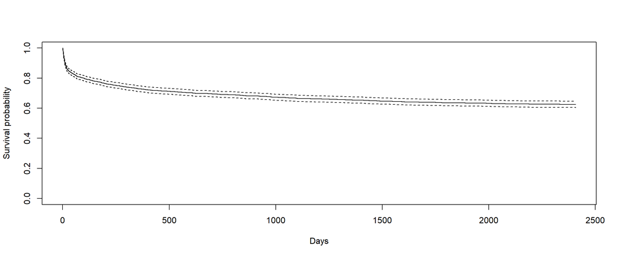

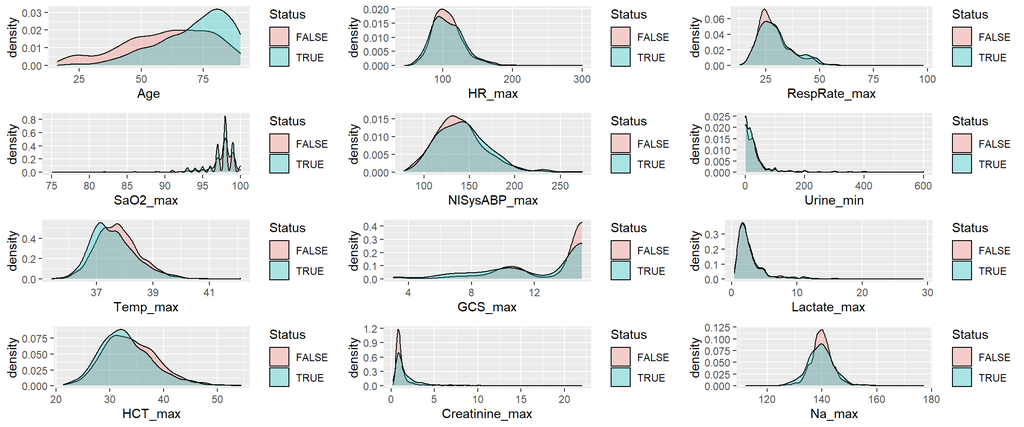

We will now fit some univariate models for these predictors.

```r
surv_object <- Surv(Days, Status)
coxmod_age <- coxph(surv_object ~ Age, data=icu_sub2)
coxmod_HR <- coxph(surv_object ~ HR_max, data=icu_sub2)
coxmod_RR <- coxph(surv_object ~ RespRate_max, data=icu_sub2)
coxmod_O2 <- coxph(surv_object ~ SaO2_max, data=icu_sub2)
coxmod_SBP <- coxph(surv_object ~ NISysABP_max, data=icu_sub2)
coxmod_U <- coxph(surv_object ~ Urine_min, data=icu_sub2)
coxmod_temp <- coxph(surv_object ~ Temp_max, data=icu_sub2)
coxmod_GCS <- coxph(surv_object ~ GCS_max, data=icu_sub2)
coxmod_lactate <- coxph(surv_object ~ Lactate_max, data=icu_sub2)
coxmod_HCT <- coxph(surv_object ~ HCT_max, data=icu_sub2)
coxmod_Cr <- coxph(surv_object ~ Creatinine_max, data=icu_sub2)
coxmod_Na <- coxph(surv_object ~ Na_max, data=icu_sub2)
# display the results
data.frame(rbind(summary(coxmod_age)$coefficients, summary(coxmod_HR)$coefficients,
summary(coxmod_RR)$coefficients, summary(coxmod_O2)$coefficients,
summary(coxmod_SBP)$coefficients, summary(coxmod_U)$coefficients,
summary(coxmod_temp)$coefficients, summary(coxmod_GCS)$coefficients,
summary(coxmod_lactate)$coefficients, summary(coxmod_HCT)$coefficients,
summary(coxmod_Cr)$coefficients, summary(coxmod_Na)$coefficients))
```

|  | coef | exp.coef. | se.coef. | z | Pr...z.. |
| --- | --- | --- | --- | --- | --- |
| Age | 0.033549811 | 1.0341190 | 0.002500182 | 13.418949 | 4.683064e-41 |
| HR_max | 0.002779443 | 1.0027833 | 0.001647579 | 1.686987 | 9.160587e-02 |
| RespRate_max | 0.014719540 | 1.0148284 | 0.004320335 | 3.407037 | 6.567227e-04 |
| SaO2_max | -0.020685206 | 0.9795273 | 0.016313967 | -1.267945 | 2.048178e-01 |
| NISysABP_max | 0.003502598 | 1.0035087 | 0.001402309 | 2.497735 | 1.249895e-02 |
| Urine_min | -0.001925183 | 0.9980767 | 0.000717925 | -2.681594 | 7.327233e-03 |
| Temp_max | -0.196578503 | 0.8215368 | 0.049298379 | -3.987525 | 6.676626e-05 |
| GCS_max | -0.082041364 | 0.9212339 | 0.010612384 | -7.730720 | 1.069401e-14 |
| Lactate_max | 0.057782574 | 1.0594846 | 0.016664719 | 3.467360 | 5.255980e-04 |
| HCT_max | -0.025206607 | 0.9751084 | 0.007590586 | -3.320772 | 8.976878e-04 |

[output cut: 2 more lines]

We now fit some multivariate models.

1. Full subset of predictors `cox_mv_all`
2. Only those significant in the univariate models `cox_mv_uni`

```r
surv_object_c <- Surv(icu_sub2c$Days, icu_sub2c$Status)
# use all variables
coxmod_mv_all <- coxph(surv_object_c ~ Age + HR_max + RespRate_max + SaO2_max + NISysABP_max + Urine_min + Temp_max + GCS_max + Lactate_max + HCT_max + Creatinine_max + Na_max, data=icu_sub2c)
show_simple_sum(coxmod_mv_all)
```

```
##                         coef exp.coef.     se.coef.          z     Pr...z..
## Age             0.0328686234 1.0334148 0.0027486505 11.9580948 5.889773e-33
## HR_max          0.0040203059 1.0040284 0.0017030708  2.3606217 1.824433e-02
## RespRate_max    0.0036678101 1.0036745 0.0054167281  0.6771265 4.983257e-01
## SaO2_max       -0.0372253832 0.9634590 0.0173712712 -2.1429280 3.211888e-02
## NISysABP_max    0.0025187355 1.0025219 0.0014070571  1.7900734 7.344211e-02
## Urine_min      -0.0005791792 0.9994210 0.0007725334 -0.7497141 4.534269e-01
## Temp_max       -0.1979935467 0.8203751 0.0544572473 -3.6357612 2.771610e-04
## GCS_max        -0.1043350072 0.9009234 0.0138724549 -7.5210197 5.435064e-14
## Lactate_max     0.0503769324 1.0516674 0.0189938584  2.6522748 7.995144e-03
## HCT_max        -0.0271662860 0.9731994 0.0087220284 -3.1146752 1.841475e-03
## Creatinine_max  0.0839992315 1.0876281 0.0171472854  4.8986898 9.647784e-07
## Na_max         -0.0244340391 0.9758621 0.0084493770 -2.8918155 3.830229e-03
##                           test df       pvalue
## Wald test             278.4300 12 1.562337e-52
## Likelihood ratio test 300.9833 12 2.919117e-57
## Score (logrank) test  291.4059 12 2.987010e-55
```

```r
# use only siginificant variables, according to the univariate models
coxmod_mv_uni <- coxph(surv_object_c ~ Age + RespRate_max + NISysABP_max + Urine_min + Temp_max + GCS_max + Lactate_max + HCT_max + Creatinine_max, data=icu_sub2c)
show_simple_sum(coxmod_mv_uni)
```

```
##                         coef exp.coef.     se.coef.          z     Pr...z..
## Age             0.0321832393 1.0327067 0.0027457963 11.7209131 9.959275e-32
## RespRate_max    0.0042227577 1.0042317 0.0052014995  0.8118347 4.168865e-01
## NISysABP_max    0.0025517176 1.0025550 0.0014083617  1.8118340 7.001185e-02
## Urine_min      -0.0007802114 0.9992201 0.0007712887 -1.0115685 3.117444e-01
## Temp_max       -0.1720547601 0.8419331 0.0541889117 -3.1750916 1.497892e-03
## GCS_max        -0.0954797270 0.9089368 0.0137029143 -6.9678409 3.218418e-12
## Lactate_max     0.0567948295 1.0584386 0.0187449070  3.0298806 2.446505e-03
## HCT_max        -0.0263305627 0.9740131 0.0085009738 -3.0973584 1.952536e-03
## Creatinine_max  0.0852523093 1.0889918 0.0173088368  4.9253633 8.420377e-07
##                           test df       pvalue
## Wald test             260.5100  9 6.005030e-51
## Likelihood ratio test 283.8232  9 7.010649e-56
## Score (logrank) test  272.6358  9 1.638299e-53
```

```r
# Accoding to the result of coxmod_mv_all, just use only significant vars
coxmod_mv_all_redc <- coxph(surv_object_c ~ Age + HR_max + SaO2_max + Temp_max + GCS_max + Lactate_max + HCT_max + Creatinine_max + Na_max, data=icu_sub2c)
show_test(coxmod_mv_all_redc) # show only test results because of page restriction
```

```
##                           test df       pvalue
## Wald test             275.5600  9 3.935870e-54
## Likelihood ratio test 296.8813  9 1.197089e-58
## Score (logrank) test  287.8221  9 9.965961e-57
```

```r
# Accoding to the result of coxmod_mv_uni, just use only significant vars
coxmod_mv_uni_redc <- coxph(surv_object_c ~ Age + Temp_max + GCS_max + Lactate_max + HCT_max + Creatinine_max, data=icu_sub2c)
show_test(coxmod_mv_uni_redc) # show only test results because of page restriction
```

```
##                           test df       pvalue
## Wald test             256.6400  6 1.565689e-52
## Likelihood ratio test 278.9843  6 2.591894e-57
## Score (logrank) test  267.9849  6 5.853762e-55
```

```r
# display AICs of models
AIC(coxmod_mv_all, coxmod_mv_uni, coxmod_mv_all_redc, coxmod_mv_uni_redc)
```

|  | df | AIC |
| --- | --- | --- |
| coxmod_mv_all | 12 | 9027.128 |
| coxmod_mv_uni | 9 | 9038.289 |
| coxmod_mv_all_redc | 9 | 9025.230 |
| coxmod_mv_uni_redc | 6 | 9037.127 |

```r
# display results of anova, just show p values to reduce page
print(anova(coxmod_mv_all_redc, coxmod_mv_all)[[4]][2])
```

```
## [1] 0.250654
```

We compared Akaike’s Information Criterion (AIC) of four models: `coxmod_mv_all`: a model with all variables , `coxmod_mv_uni`: a model with only significant variables in univariate models , `coxmod_mv_all_redc`: a model with non-significant variables removed from `coxmod_mv_all`, and `coxmod_mv_uni_redc`: a model with non-significant variables removed from `coxmod_mv_uni`. We found that the `coxmod_mv_all_redc` was the best model and chose it as our final model. Also, according to the p-value of anova, it is acceptable to choose a model with fewer variables. It was shown that the evaluations of the model by the AIC and anova function was improved by removing the variables `RespRate_max`, `NISysABP_max`, `Urine_min`.

```r
# confirm PH assumption
prop <- cox.zph(coxmod_mv_all_redc)
prop
```

```
##                 chisq df       p
## Age             1.028  1 0.31058
## HR_max         14.867  1 0.00012
## SaO2_max        0.324  1 0.56901
## Temp_max        0.269  1 0.60397
## GCS_max        18.285  1 1.9e-05
## Lactate_max    31.174  1 2.4e-08
## HCT_max         2.244  1 0.13417
## Creatinine_max  0.607  1 0.43604
## Na_max          0.329  1 0.56644
## GLOBAL         57.746  9 3.6e-09
```

Confirming the proportional hazard assumption of each variable by coxzph, the p-values are small for three variables, and the global p-value are also low. Therefore, we see that there are violations that must be addressed in this model.

```r
om.split <- survSplit( Surv(Days, Status) ~ ., data = icu_sub2c, cut=c(365, 730), episode= "tgroup")
coxmod_strata <- coxph(Surv(Days, Status) ~ Age + HR_max:strata(tgroup) + SaO2_max + Temp_max + HCT_max + Creatinine_max + Na_max, data=om.split)
cox.zph(coxmod_strata)
```

```
##                       chisq df    p
## Age                   0.137  1 0.71
## SaO2_max              0.506  1 0.48
## Temp_max              0.145  1 0.70
## HCT_max               1.526  1 0.22
## Creatinine_max        0.702  1 0.40
## Na_max                1.720  1 0.19
## HR_max:strata(tgroup) 4.177  3 0.24
## GLOBAL                9.538  9 0.39
```

```r
show_simple_sum(coxmod_strata)
```

```
##                                       coef exp.coef.    se.coef.         z
## Age                            0.032832700 1.0333776 0.002716817 12.084987
## SaO2_max                      -0.026830149 0.9735266 0.017899510 -1.498932
## Temp_max                      -0.076550029 0.9263066 0.052081650 -1.469808
## HCT_max                       -0.021537375 0.9786929 0.008722353 -2.469216
## Creatinine_max                 0.100314009 1.1055180 0.017064117  5.878652
## Na_max                        -0.014805388 0.9853037 0.008644662 -1.712662
## HR_max:strata(tgroup)tgroup=1  0.009072530 1.0091138 0.001796728  5.049473
## HR_max:strata(tgroup)tgroup=2 -0.007468377 0.9925594 0.006177306 -1.209002
## HR_max:strata(tgroup)tgroup=3 -0.010628687 0.9894276 0.004659188 -2.281232
##                                   Pr...z..
## Age                           1.267906e-33
## SaO2_max                      1.338913e-01
## Temp_max                      1.416137e-01
## HCT_max                       1.354094e-02
## Creatinine_max                4.136203e-09
## Na_max                        8.677466e-02
## HR_max:strata(tgroup)tgroup=1 4.430294e-07
## HR_max:strata(tgroup)tgroup=2 2.266619e-01
## HR_max:strata(tgroup)tgroup=3 2.253473e-02
##                           test df       pvalue
## Wald test             223.9900  9 3.036802e-43
## Likelihood ratio test 247.7759  9 2.940680e-48
## Score (logrank) test  235.3070  9 1.253770e-45
```

First, Days were grouped by <365, 365-730, >730 to three groups, and only HR_max was used to switch coefficients at the delimitations. Since GCS and Lactate are difficult to hold the PH assumptions even after this process, we decided to remove them as explanatory variables. We then confirmed that the PH assumption was valid for all variables and global. This process limited the significant variables to Age, HCT_max, and Creatine_max. For HR with stratification, the variables are significant for periods of less than 365 days and more than 730 days, but are no longer significant for the periods in between.

Similar to our `reduced_interactions2` GLM model, `coxmod_strata` showed for every year increase of `Age`, there is ~3% increase in mortality. Unsurprisingly, increases in maximum oxygen saturation (OR 0.97) and haematocrit were protective (OR 0.98). Also unsurprisingly, increases in creatinine (suggestive of poorer kidney function) increased mortality (OR 1.1). Interestingly, increase in maximum temperature was protective (OR 0.92); so was increase in maximum heart rate for `Days` > 365.

```r
icu_sub2u <- icu_patients_df0 %>% dplyr::select(Days, Status, Age, HR_max, RespRate_max, SaO2_max, NISysABP_max, Urine_min, Temp_max, GCS_max, Lactate_max, HCT_max, Creatinine_max, Na_max)
icu_sub2uc <- na.omit(icu_sub2u)

om.split.u <- survSplit( Surv(Days, Status) ~ ., data = icu_sub2uc, cut=c(365, 730), episode= "tgroup")
coxmod_strata_u <- coxph(Surv(Days, Status) ~ Age + HR_max:strata(tgroup) + SaO2_max + Temp_max + HCT_max + Creatinine_max + Na_max, data=om.split.u)
#cox.zph(coxmod_strata_u)
show_simple_sum(coxmod_strata_u)
```

```
##                                      coef exp.coef.   se.coef.          z
## Age                            0.05081687 1.0521302 0.02997057  1.6955592
## SaO2_max                       0.12243876 1.1302499 0.14756565  0.8297240
## Temp_max                      -0.29334717 0.7457632 0.49917708 -0.5876615
## HCT_max                       -0.03766198 0.9630384 0.08755087 -0.4301725
## Creatinine_max                 0.46475991 1.5916320 0.35010058  1.3275040
## Na_max                        -0.05847782 0.9431992 0.07245750 -0.8070637
## HR_max:strata(tgroup)tgroup=1 -0.01117582 0.9888864 0.02596866 -0.4303581
## HR_max:strata(tgroup)tgroup=2 -0.10094003 0.9039872 0.10063922 -1.0029891
## HR_max:strata(tgroup)tgroup=3  0.09736730 1.1022652 0.04703329  2.0701785
##                                 Pr...z..
## Age                           0.08996939
## SaO2_max                      0.40669484
## Temp_max                      0.55675950
## HCT_max                       0.66707017
## Creatinine_max                0.18434202
## Na_max                        0.41962978
## HR_max:strata(tgroup)tgroup=1 0.66693515
## HR_max:strata(tgroup)tgroup=2 0.31586614
## HR_max:strata(tgroup)tgroup=3 0.03843563
##                           test df    pvalue
## Wald test              8.14000  9 0.5203770
## Likelihood ratio test 12.59906  9 0.1816031
## Score (logrank) test  10.17669  9 0.3363714
```

With only $n=30$ observations without missing values, this model is unreliable. Indeed, most of the model coefficients have lost significance with the exception of `HR_max` for `Days` >730. However, it is worth noting the direction of influence has flipped compared to the original model (OR 1.1 vs. 0.99) with $n=1608$. We would recommend not making any inferences from this model.